# Analytathon-3

# 6. PART 2: CONCLUSION

Looking at the sucessfull trade startergies, the same were applied on historic data 2019 and 2020.The graph below clearly shows the stratergies failed for 2019 resulting in a loss with negative values, But gave a good trade profit returns for 2020. Where as for year 2021 within mid of year we have gained highest profit compared to other years and by continuing the same trade stratergies we can double the profit in comming months.

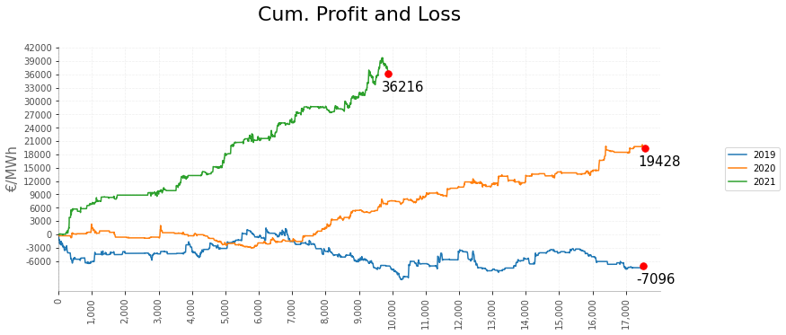

Below figure provides information on all the trade wins and lose.

```
Profit Loss data for year 2019
Total trades: 7641
Total Available trades: 17520
Percentage of trades: 43.61%
------------------------------------
Winning trades: 2864
Loss trades: 4777
------------------------------------
Winning Ratio: 37.48%
Loss Ratio: 62.52%
------------------------------------
Average Win trades: 33.69
Average Loss trades: -21.69
------------------------------------
Max Win trades: 368.853
Max Loss trades: -311.05

Profit Loss data for year 2020
Total trades: 6566
Total Available trades: 17568
Percentage of trades: 37.37%
------------------------------------
Winning trades: 2915
Loss trades: 3651
------------------------------------
Winning Ratio: 44.4%
Loss Ratio: 55.6%
------------------------------------
Average Win trades: 27.97
Average Loss trades: -17.01
------------------------------------
Max Win trades: 421.8399999999999
Max Loss trades: -224.61

Profit Loss data for year 2021
Total trades: 4959
Total Available trades: 9888
Percentage of trades: 50.15%
------------------------------------
Winning trades: 2499
Loss trades: 2460
------------------------------------
Winning Ratio: 50.39%
Loss Ratio: 49.61%
------------------------------------
Average Win trades: 43.05
Average Loss trades: -29.01
------------------------------------
Max Win trades: 1091.05
Max Loss trades: -336.73
```

# 7. FUTURE SOLUTIONS

A Machine Learning model can be implemented to predict the right trade stratergies for the data given and all other factors and can be further implemented as reinforcement ML model to make a sequence of decisions based on the current market affairs and trading.

# 8. REFERENCES

- https://www.machinelearningplus.com/time-series/vector-autoregression-examples-python/
- https://info.ams-insights.com/machine-learning-market-research#additional_resources
- https://www.analyticsvidhya.com/blog/2018/10/predicting-stock-price-machine-learningnd-deep-learning-techniques-python/
- https://core.ac.uk/download/pdf/326318195.pdf